# Herramientas para el Análisis de Series de Tiempo en R - Ejercitación 3

Oficina de la CEPAL en Buenos Aires

Octubre 2021

## Objetivos

1. Estimar un modelo de corrección de errores para la tasa de préstamos personales como función de la de política monetaria, y
2. Resolver el ejercicio pendiente, que consistía en estimar la elasticidad empleo-producto mediante una regresión lineal controlando y sin controlar por el tipo de cambio real.

# Ejercitación de la clase 3: modelo de corrección de errores

Empezamos limpiando la memoria, cargando las librerías y estableciendo el directorio. En esta ejercitación sumamos `fUnitRoots`, que tiene una función para el test ADF de raíz unitaria.

```r
##  Limpiar la memoria
rm(list=ls())

## Apertura de librerias
library(tidyverse)  #Manejo de bases de datos y otros
library(openxlsx)   #Lectura de xlsx
library(lubridate)  #Manejo de variables en formato fecha
library(zoo)        #Series de tiempo
library(forecast)   #Pronosticos
library(ggfortify)  #Graficos
library(kableExtra) #Formato tablas
# install.packages("fUnitRoots")
library(fUnitRoots) #adfTest y otros

## Establecemos el directorio
setwd("C:/Users/Garlan/Desktop/CEPAL/Curso Series")

options(scipen=9999) #Evita que los resultados se impriman en notación científica
```

## Carga de datos

Vamos a armar un modelo con datos de las tasas que ya mensualizamos en ejercicios anteriores. Levantamos los datos con `read.xlsx()`.

```r
tasas <- read.xlsx("Clase 3.xlsx", sheet="tasas_mensual")

head(tasas)
```

```
##   year month tasa_polmon prestamos_personales  Fecha
## 1 2016     1    31.41250             43.35600 2016-1
## 2 2016     2    30.59737             42.21579 2016-2
## 3 2016     3    37.43571             42.27476 2016-3
## 4 2016     4    38.00000             43.14381 2016-4
## 5 2016     5    36.94048             43.13524 2016-5
## 6 2016     6    32.66250             42.29200 2016-6
```

En primer lugar, las convertimos a series de tiempo con `ts()`.

```r
class(tasas$tasa_polmon) #Las variables son numéricas
```

```
## [1] "numeric"
```

```r
tasas <- tasas %>%
  mutate(tasa_polmon = ts(tasa_polmon, start = c(2016,1),frequency = 12),
         prestamos_personales =ts(prestamos_personales,start=c(2016,1),frequency=12))


class(tasas$tasa_polmon) #Ahora son time series
```

```
## [1] "ts"
```

El gráfico a continuación muestra que hacia principios de 2020 la tasa de política monetaria se fijó en 38%. Un modelo de corrección de errores en esta última etapa no tendría mucho sentido porque (i) no hay variabilidad de la variable explicativa, que es una propiedad deseable para realizar la estimación, y (ii) esperamos que la tasa se mantenga constante hasta que haya otro cambio en la política monetaria.

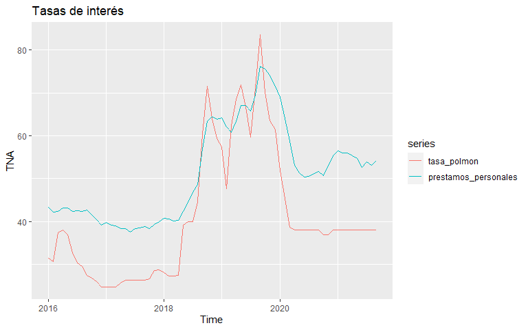

```r
attach(tasas)
autoplot(cbind(tasa_polmon,prestamos_personales))+
  ylab("TNA")+
  ggtitle("Tasas de interés")
```

A los fines de este ejercicio vamos a truncar la muestra mediante `filter()`, como si estuviéramos realizando el pronóstico en diciembre de 2019. Esto, además, nos va a permitir constrastar nuestra proyección con la dinámica efectiva de las tasas de interés. A veces al trabajar con series de tiempo es necesario aclarar que queremos la función del paquete `dplyr`, porque hay funciones para filtrar series que tienen el mismo nombre que `filter()`. Luego hay que volver a convertir todo a series de tiempo (el formato se pierde al aplicar el filtro).

```r
tasas <- tasas %>%
  dplyr::filter(year<2020) %>%
  mutate(across(everything(), .fns = ts, start = c(2016,1), frequency = 12))
```

Finalmente, aplicar `attach()` sobre la nueva base. Una buena práctica es aplicar `detach()` sobre la base anterior, para evitar confusiones en caso de que las variables tengan el mismo nombre en una y otra.

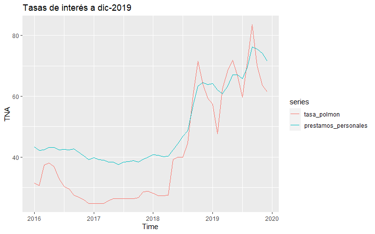

```r
detach(tasas)
attach(tasas)
autoplot(cbind(tasa_polmon,prestamos_personales))+
  ylab("TNA")+
  ggtitle("Tasas de interés a dic-2019")
```

Tomemos 5 o 10’ para correr lo que hicimos hasta acá y obtener el orden de integración de las series:

- Estimar las ACF.
- Aplicar el test ADF.
- Si no son estacionarias, diferenciar e iterar.

## Estacionariedad de las series

Estimamos las funciones de autocorrelación mediante `Acf()`.

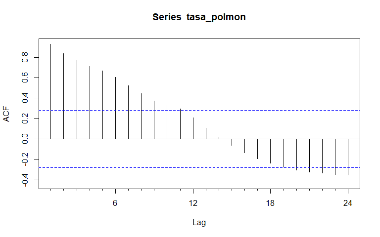

```r
Acf(tasa_polmon)
```

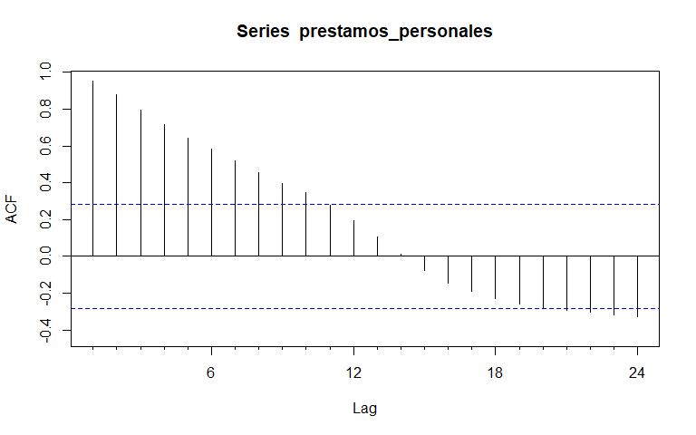

```r
Acf(prestamos_personales)
```

El decaimiento es marcadamente no exponencial, lo cual sugiere que no son estacionarias. Podemos testearlo formalmente mediante el test de Dickey-Fuller (aumentado), con la función `adfTest()`.

```r
adfTest(tasa_polmon, type="c") #Constant
```

```
##
## Title:
##  Augmented Dickey-Fuller Test
##
## Test Results:
##   PARAMETER:
##     Lag Order: 1
##   STATISTIC:
##     Dickey-Fuller: -1.1681
##   P VALUE:
##     0.6203
##
## Description:
##  Wed Oct 20 11:57:56 2021 by user: Garlan
```

```r
adfTest(prestamos_personales, type="c")
```

```
##
## Title:
##  Augmented Dickey-Fuller Test
##
## Test Results:
##   PARAMETER:
##     Lag Order: 1
##   STATISTIC:
##     Dickey-Fuller: -0.5329
##   P VALUE:
##     0.8505
##
## Description:
##  Wed Oct 20 11:57:56 2021 by user: Garlan
```

```r
#adfTest(tasa_polmon, type="ct") #Constant & trend
#adfTest(prestamos_personales, type="ct")
```

En ninguno de los casos los datos permiten rechazar que las series presenten raíz unitaria (tenemos p-valores mayores al 10%). Es decir, serían series no estacionarias, con tendencia estocástica. Las diferenciamos y repetimos el test pero sin tendencia ni constante (si las diferencias tuvieran tendencia determinística, queremos que el test lo identifique y no rechace).

- Calculamos las diferencias, inspeccionamos el gráfico, la función de autocorrelación y el ADF.

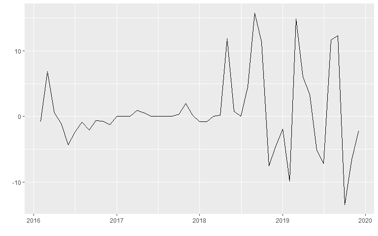

```r
dtasa_polmon <-  tasa_polmon - stats::lag(tasa_polmon,-1)
autoplot(dtasa_polmon)
```

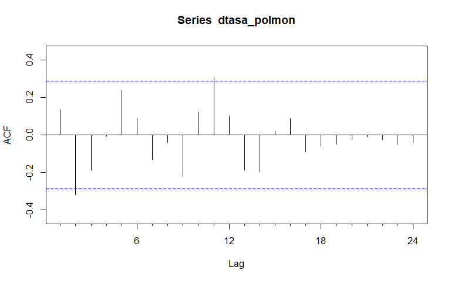

```r
Acf(dtasa_polmon)
```

```r
adfTest(dtasa_polmon[-1],type = "nc") #No constant
```

```
##
## Title:
##  Augmented Dickey-Fuller Test
##
## Test Results:
##   PARAMETER:
##     Lag Order: 1
##   STATISTIC:
##     Dickey-Fuller: -5.9968
##   P VALUE:
##     0.01
##
## Description:
##  Wed Oct 20 11:57:57 2021 by user: Garlan
```

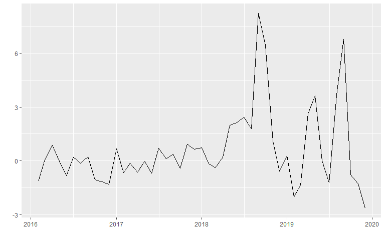

```r
dprestamos_personales <- prestamos_personales - stats::lag(prestamos_personales,-1)
autoplot(dprestamos_personales)
```

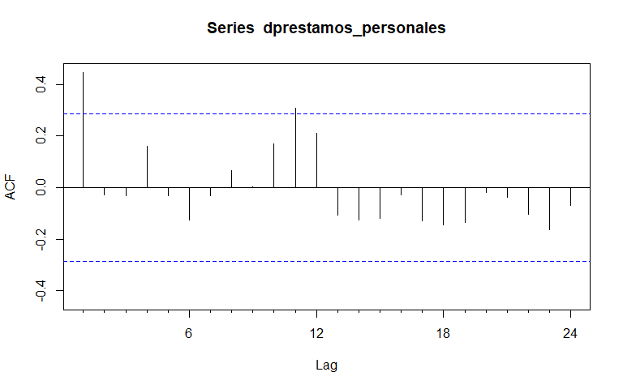

```r
Acf(dprestamos_personales)
```

```r
adfTest(dprestamos_personales[-1], type="nc")
```

```
##
## Title:
##  Augmented Dickey-Fuller Test
##
## Test Results:
##   PARAMETER:
##     Lag Order: 1
##   STATISTIC:
##     Dickey-Fuller: -4.061
##   P VALUE:
##     0.01
##
## Description:
##  Wed Oct 20 11:57:58 2021 by user: Garlan
```

Diferenciando una vez se eliminó la tendencia estocástica, por lo que ambas series son integradas de orden 1.

- Nota: el test ADF no es robusto a la heteroscedasticidad, que es cuando la varianza del proceso no es constante a lo largo de la muestra. Por simplicidad no estamos contemplando esa posibilidad, pero correspondería testearla (el gráfico sugiere que hay), utilizar otros test que sí sean robustos (por ejemplo, el de Phillips-Perron) o aplicar logs para reducir la variabilidad.

## Cointegración

Habiendo establecido que las series son integradas del mismo orden, queremos ver si están cointegradas (si comparten tendencia), para estimar su relación de largo plazo. Siguiendo a Engle y Granger, si las series están cointegradas, los residuos de una regresión entre ellas son un proceso estacionario, lo cual podemos testear mediante ADF.

- Estimamos el modelo.
- Guardamos los residuos como serie de tiempo.
- `tsdisplay()` permite un diagnóstico rápido de los residuos.
- Aplicamos el test de raíz unitaria sin constante ni tendencia a los residuos.

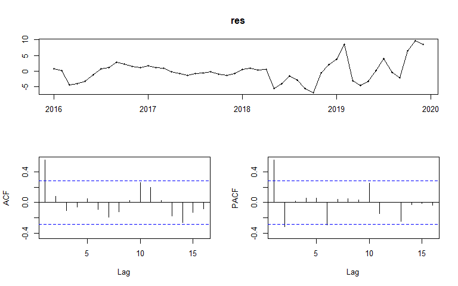

```r
modelo1 <- tslm(prestamos_personales ~ tasa_polmon)

res <- ts(modelo1$res, start = c(2016,1), frequency = 12)

tsdisplay(res)
```

```r
adfTest(res, type = "nc")
```

```
##
## Title:
##  Augmented Dickey-Fuller Test
##
## Test Results:
##   PARAMETER:
##     Lag Order: 1
##   STATISTIC:
##     Dickey-Fuller: -3.651
##   P VALUE:
##     0.01
##
## Description:
##  Wed Oct 20 11:57:58 2021 by user: Garlan
```

El test sugiere que las series están cointegradas.

- Nota: por simplicidad estamos usando el p-valor que surge de la función, pero en rigor los valores críticos del test sobre los residuos (estimados) son distintos de los del ADF aplicado a una serie. Para una muestra de aproximadamente 50 observaciones y una relación entre 2 variables, [son](https://link.springer.com/content/pdf/bbm%253A978-3-319-98282-3%252F1.pdf) -4,32 al 1%, -3,67 al 5% y -3,28 al 10%. En este caso estamos cerca de rechazar al 5%.

Usemos 5’ o 10’ para estimar el MCE, aprovechando que ya habíamos calculado las variables en diferencias y los residuos de la relación de largo plazo.

- Rezagar `res` con `stats::lag()`.
- Estimar el modelo de largo plazo.
- Estimar el modelo de corrección de errores.

## Estimación del MCE

Estimamos la relación de largo plazo y el modelo de corrección de errores. Respectivamente, vamos a llamar a los coeficientes `lp` y `ce`.

$$\text{prestamos_personales}_t = lp_1+lp_2 \ \text{tasa_polmon}_t+\varepsilon_t$$
$$\Delta \text{prestamos_personales}_t = ce_1+ce_2 \ \Delta \text{tasa_polmon}_t+ce_3 \ \varepsilon_{t-1} + \epsilon_t$$
Para estimar los modelos usamos `tslm()`. En el caso de la relación de corto plazo, primero tenemos que rezagar los residuos (que ya habíamos calculado porque surgen de la relación de cointegración). Al hacerlo tenemos que eliminar la última observación, y aclarar que la nueva serie comienza en el 2do mes de 2016 mediante `ts()`. Nuevamente, `summary()` nos permite evaluar los primeros resultados, incluyendo la significancia estadística.

```r
mlp <- tslm(prestamos_personales ~ tasa_polmon)

L.res <- ts(stats::lag(res,-1)[-48], start = c(2016,2), frequency=12)
mce <- tslm(dprestamos_personales ~ dtasa_polmon + L.res)

summary(mlp)
```

```
##
## Call:
## tslm(formula = prestamos_personales ~ tasa_polmon)
##
## Residuals:
##     Min      1Q  Median      3Q     Max
## -6.7815 -1.6907 -0.2424  1.1301  9.5843
##
## Coefficients:
##             Estimate Std. Error t value            Pr(>|t|)
## (Intercept) 20.96567    1.30002   16.13 <0.0000000000000002 ***
## tasa_polmon  0.68687    0.02874   23.90 <0.0000000000000002 ***
## ---
## Signif. codes:  0 '***' 0.001 '**' 0.01 '*' 0.05 '.' 0.1 ' ' 1
##
## Residual standard error: 3.513 on 46 degrees of freedom
## Multiple R-squared:  0.9255, Adjusted R-squared:  0.9239
## F-statistic: 571.3 on 1 and 46 DF,  p-value: < 0.00000000000000022
```

```r
summary(mce)
```

```
##
## Call:
## tslm(formula = dprestamos_personales ~ dtasa_polmon + L.res)
##
## Residuals:
##     Min      1Q  Median      3Q     Max
## -2.6078 -0.6240 -0.2122  0.6821  3.1488
##
## Coefficients:
##              Estimate Std. Error t value        Pr(>|t|)
## (Intercept)   0.37676    0.17277   2.181          0.0346 *
## dtasa_polmon  0.25369    0.02904   8.735 0.0000000000364 ***
## L.res        -0.34294    0.05287  -6.487 0.0000000649039 ***
## ---
## Signif. codes:  0 '***' 0.001 '**' 0.01 '*' 0.05 '.' 0.1 ' ' 1
##
## Residual standard error: 1.176 on 44 degrees of freedom
## Multiple R-squared:  0.7235, Adjusted R-squared:  0.7109
## F-statistic: 57.56 on 2 and 44 DF,  p-value: 0.0000000000005228
```

Vemos que todos los coeficientes son individualmente significativos, y el ajuste es elevado tanto para el largo como el corto plazo. A nivel económico, tienen el signo y magnitud esperados. El coeficiente de los residuos es de particular interes: debe ser negativo y con módulo menor a 1 para que el modelo retorne a una posición de equilibrio luego de un shock.

Para ajustar mejor el pronóstico y disminuir posibles sesgos podemos ver si hay autocorrelación remanente en el MCE. Para eso, usamos `Acf()` o `tsdisplay()` e inspeccionamos el correlograma de los residuos de la relación de corto plazo.

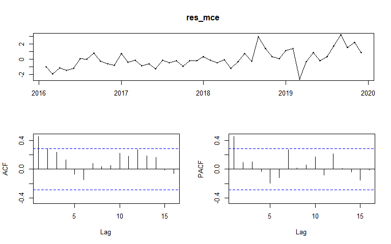

```r
res_mce <- ts(mce$res, start = c(2016,2), frequency = 12)

tsdisplay(res_mce)
```

En efecto, el correlograma de los residuos sugiere que siguen un AR(1). Reestimamos el MCE pero incluyendo un rezago de la variable dependiente, de manera que la nueva ecuación es:
$$\Delta \text{prestamos_personales}_t = ce_1+ce_2 \ \Delta \text{tasa_polmon}_t+ce_3 \ \varepsilon_{t-1} + ce_4 \ \Delta \text{prestamos_personales}_{t-1} + \epsilon_t$$
Primero rezagamos `dprestamos_personales`, y nuevamente perdemos la última observación, pero además hay que agregar un `NA` para que los vectores tengan la misma longitud. Esto lo hacemos creando un vector `c()` cuyo primer elemento es un `NA`, mientras que los restantes son los de la serie rezagada.

```r
L.dprestamos_personales <- ts(c(NA,stats::lag(dprestamos_personales,-1)[-47]),
                             start = c(2016,3), frequency=12)

mce <- tslm(dprestamos_personales ~ dtasa_polmon+L.res+L.dprestamos_personales)
summary(mce)
```

```
##
## Call:
## tslm(formula = dprestamos_personales ~ dtasa_polmon + L.res +
##     L.dprestamos_personales)
##
## Residuals:
##     Min      1Q  Median      3Q     Max
## -2.9749 -0.6020 -0.1298  0.6013  2.7598
##
## Coefficients:
##                         Estimate Std. Error t value         Pr(>|t|)
## (Intercept)              0.20347    0.16472   1.235         0.223586
## dtasa_polmon             0.25959    0.02589  10.029 0.00000000000103 ***
## L.res                   -0.21314    0.05903  -3.610         0.000809 ***
## L.dprestamos_personales  0.32500    0.09094   3.574         0.000900 ***
## ---
## Signif. codes:  0 '***' 0.001 '**' 0.01 '*' 0.05 '.' 0.1 ' ' 1
##
## Residual standard error: 1.044 on 42 degrees of freedom
##   (1 observation deleted due to missingness)
## Multiple R-squared:  0.7888, Adjusted R-squared:  0.7737
## F-statistic: 52.28 on 3 and 42 DF,  p-value: 0.00000000000003101
```

Nuevamente inspeccionamos los residuos aplicando `tsdisplay()`.

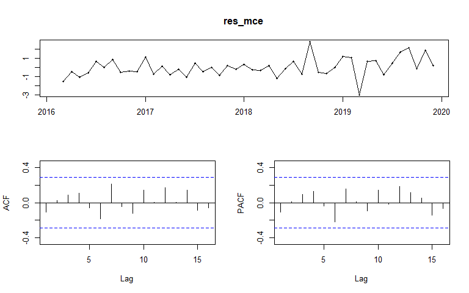

```r
res_mce <- ts(mce$res, start = c(2016,2), frequency = 12)

tsdisplay(res_mce)
```

Se verifica la ausencia de autocorrelación remanente, así que vamos a usar la ecuación:
$$\Delta \text{prestamos_personales}_t = ce_1+ce_2 \ \Delta \text{tasa_polmon}_t+ce_3 \ \varepsilon_{t-1} + ce_4 \ \Delta \text{prestamos_personales}_{t-1}+ \epsilon_t$$
donde $\varepsilon$ sigue siendo el residuo de la relación de largo plazo. Guardamos los coeficientes para más aldelante y los mostramos en una tabla mediante `kbl()`.

```r
lp <- mlp$coefficients
ce <- mce$coefficients

tabla <- data.frame(c(lp,"",""), ce) %>%  #Espacios vacíos para completar la columna
  rename("Modelo LP"=1,"MCE"=2)           #Nombres columnas
rownames(tabla) <-  c("Intercepto",       #Nombres filas
                      "Tasa polmon",
                      "Corrección de errores",
                      "Autorregresivo")

kbl(tabla, align=rep('c', 3)) %>%  #Centrar las 7 columnas
  kable_styling(bootstrap_options = c("striped", "hover"), #Formato de filas
                font_size = 14) #Tamaño de letra
```

|  | Modelo LP | MCE |
| --- | --- | --- |
| Intercepto | 20.9656711467709 | 0.2034748 |
| Tasa polmon | 0.68686642648123 | 0.2595928 |
| Corrección de errores |  | -0.2131383 |
| Autorregresivo |  | 0.3250032 |

## Pronóstico

En base al MCE, proyectamos la tasa de préstamos personales a 6 meses vista suponiendo que la tasa de política monetaria cae a 38% y se mantiene constante en los meses siguientes. Primero extendemos las variables, donde luego vamos a cargar las proyecciones de la tasa de política monetaria, la de préstamos personales y la del desvío respecto a la relación de largo plazo.

- Esto se logra creando un vector `c()` cuyos primeros elementos sean los valores de la serie, y los últimos 6 valores `NA`.
- `rep()` permite repetir un valor n veces dentro de un vector.

```r
tasa_polmon <- ts(c(tasa_polmon,rep(NA,6)),start = c(2016,1),frequency=12)
prestamos_personales <- ts(c(prestamos_personales,rep(NA,6)),
                           start= c(2016,1),frequency=12)
res <- ts(c(res,rep(NA,6)), start = c(2016,1), frequency = 12)
```

También creamos un vector vacío para cargar la tasa de préstamos personales estimada por la relación de largo plazo.

```r
prestamos_personales_lp <- c(rep(NA,54))
```

En segundo lugar, simulamos que la tasa de política monetaria cae a 38%, como efectivamente lo hizo. Simplemente reemplazamos los `NA` que habíamos creado en la tasa de política monetaria por 38.

```r
tasa_polmon[49:54] <- 38      #Shock: fija en 38.
```

Dada la tasa de política monetaria, podemos estimar la relación de largo plazo dentro de la muestra utilizando los coeficientes `lp`. En rigor solo necesitamos la del último período.

```r
for (t in 1:48) {
  prestamos_personales_lp[t] <- lp[1]+lp[2]*tasa_polmon[t]
}
```

Ahora hacemos la proyección usando los coeficientes del MCE guardados en `ce`. Dentro del loop, para cada período futuro:

- Pronosticamos la dependiente como una variación (estimada por el MCE) sobre el último valor conocido. Notar que el MCE usa los residuos de t-1, por lo que son conocidos, computables respecto a la relación de largo estimada en el loop anterior.
- Proyectamos la relación de largo plazo (independiente del paso anterior).
- Pronosticamos el residuo en t, como la diferencia entre el valor proyectado de `prestamos_personales` mediante el MCE y el equilibrio de largo plazo.

En la siguiente iteración, este último residuo se utiliza para calcular la proyección mediante el MCE.

```r
for (t in 49:54) {
  prestamos_personales[t] <- prestamos_personales[t-1]+ce[1]+
                            ce[2]*(tasa_polmon[t]-tasa_polmon[t-1])+ce[3]*res[t-1]+
                            ce[4]*(prestamos_personales[t-1]-prestamos_personales[t-2])

  prestamos_personales_lp[t] <- lp[1]+lp[2]*tasa_polmon[t] #Relacion de LP

  res[t] <- prestamos_personales[t] - prestamos_personales_lp[t] #Res pronosticado
}
```

Para visualizar el pronóstico, podemos aprovechar que, como al comienzo truncamos la serie, conocemos la dinámica efectiva de la tasa de préstamos personales tras este shock.

- Leemos nuevamente la base original con `read.xlsx()`.
- Pasamos a tasa de prestamos personales observada a serie de tiempo.
- Graficamos las tasas observadas, la relación de largo plazo y la proyección.

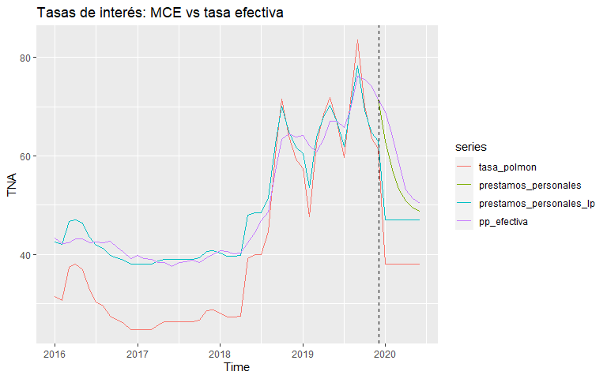

```r
tasas_efectivas <- read.xlsx("Clase 3.xlsx", sheet="tasas_mensual")
pp_efectiva <- ts(tasas_efectivas$prestamos_personales[1:54],
                  start = c(2016,1), frequency = 12)

autoplot(cbind(tasa_polmon,prestamos_personales,prestamos_personales_lp,pp_efectiva))+
  geom_vline(xintercept = 2019.92, linetype="dashed")+ #2019.92 = dic-19
  ylab("TNA")+
  ggtitle("Tasas de interés: MCE vs tasa efectiva")
```

Claramente, el ajuste mediante el MCE permitió un pronóstico más certero que el que hubiéramos generado con el modelo de largo plazo. Podríamos simular otras trayectorias de la tasa de política monetaria, por ejemplo:

- un cambio gradual en la tasa de política. En el loop cada iteración resta 0,3 al valor previo, partiendo desde el último dato conocido.

```r
for (t in 49:54) {
  tasa_polmon[t] <- tasa_polmon[t-1] - 0.3
}
```

- una tasa de política que sigue su estructura estocástica anterior. Estimamos un modelo univariado para la tasa de política monetaria mediante la función `ar()`, reconociendo que esta también tiene un componente aleatorio. Luego guardamos los coeficientes en `mu` (intercepto y 3 rezagos) y pronosticamos.

```r
modelo_univariado <- ar(tasa_polmon, method = 'ols')

mu <- c(modelo_univariado$x.intercept, modelo_univariado$ar)

for (t in 4:54) {
  tasa_polmon[t] <- mu[1]+mu[2]*tasa_polmon[t-1]+
                    mu[3]*tasa_polmon[t-2]+mu[4]*tasa_polmon[t-3]
}
```

# Consigna para la clase 4: MCE empleo

Estimar un modelo de corrección de errores para el empleo usando el PIB como regresor y con los datos de `Clase 4.xlsx`.

- Verificar estacionariedad.
- De ser necesario, aplicar diferencias logarítmicas para estimar el orden de integración.
- Verificar si la series están cointegradas.
- Estimar el MCE.